# GGPLOT: BAR CHARTS

By Ilya Moskalenko & Sita Manasa Susarla

2023

Welcome to Week 3!

In this module, we will explore how to create basic and advanced barcharts and modify them to be publication-worthy using ggplot.

After this module, students should be able to:

- Create basic graphs using ggplot
- Use advanced ggplot aesthetics to customize graphs
- Apply concepts of effective graphical design to produce professional graphs

Helpful Resources:

- ggplot Cheatsheet [link](https://raw.githubusercontent.com/rstudio/cheatsheets/main/data-visualization.pdf)
- R Brewer Palettes [link](https://r-graph-gallery.com/38-rcolorbrewers-palettes.html)
- HEX Color Palette Generator [link](https://coolors.co/)
- ggthemes List [link](https://ggplot2.tidyverse.org/reference/ggtheme.html)

```r
# It is good practice to always load your libraries first!
library(ggplot2)
library(ggthemes)
library(dplyr)
library(magrittr)
```

# PART 0

## 0.1: DATA SET BACKGROUND INFO

For this module, we will use data from a case-control study of esophageal cancer in Ille-et-Vilaine, France using a built-in dataset in R.

There are 5 variables:

agegp: Age group

alcgp: Alcohol consumption in grams/day

tobgp: Tobacco consumption in grams/day

ncases: Number of cases

ncontrols: Number of controls

```r
# Load data
# NOTE: How is loading this built-in data different from loading other datasets?
data(esoph)

# Let's view the first couple of lines of the data
# NOTE: What do you notice about the types of variables?
head(esoph)
```

|  | agegp | alcgp | tobgp | ncases | ncontrols |
| --- | --- | --- | --- | --- | --- |
| 1 | 25-34 | 0-39g/day | 0-9g/day | 0 | 40 |
| 2 | 25-34 | 0-39g/day | 10-19 | 0 | 10 |
| 3 | 25-34 | 0-39g/day | 20-29 | 0 | 6 |
| 4 | 25-34 | 0-39g/day | 30+ | 0 | 5 |
| 5 | 25-34 | 40-79 | 0-9g/day | 0 | 27 |
| 6 | 25-34 | 40-79 | 10-19 | 0 | 7 |

## 0.2: DATA PREPROCESSING

Based on the data, I am curious to see which age group has the most cases of esophageal cancer. So, to find that out, we need to first clean and subset our data.

```r
# The 'agg_agegp' data frame will contain summarized information about esophageal cancer cases by age group
agg_agegp <- esoph %>%
  # Group the data by the 'agegp' variable
  group_by(agegp) %>%
  # Summarize the grouped data by calculating the total number of cases (ncases) for each age group
  summarize(totalcases = sum(ncases))
# Display or return the 'agg_agegp' data frame, which now contains the summarized information
agg_agegp
```

| agegp | totalcases |
| --- | --- |
| 25-34 | 1 |
| 35-44 | 9 |
| 45-54 | 46 |
| 55-64 | 76 |
| 65-74 | 55 |
| 75+ | 13 |

We have the total number of cases by age group, but it may be helpful to also get a percentage of the total cases between age groups.

```r
# Add a new column 'perc_cases' to the data frame
  # Calculate the percentage of total cases for each age group
  # The calculation is done by dividing 'totalcases' by the sum of all 'totalcases' values, and then multiplying by 100
agg_agegp <- agg_agegp %>%
  mutate(perc_cases = 100*totalcases/sum(totalcases))
```

To get a better understanding of this trend, let’s visualize this data using a barchart.

# PART 1: BAR PLOT BASIC ANATOMY

## 1.1: SETTING UP INITIAL GGPLOT LAYER

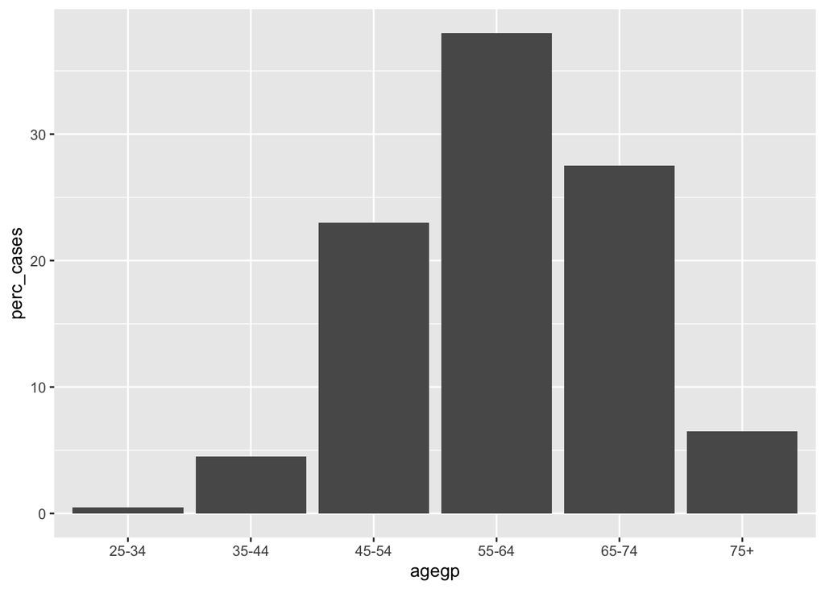

```r
# Initialize the 'barchart' object and specify the data frame 'agg_agegp' as the data source
# Use 'aes()' to define the aesthetics (mapping of variables to visual properties)
barchart <- ggplot(data = agg_agegp, # Selecting the data that will be fed into the plot
                   aes(x = agegp, # 'x=agegp' maps the 'agegp' variable to the x-axis
                       y = perc_cases)) + # 'y=perc_cases' maps the 'perc_cases' variable to the y-axis

  # Add a bar layer to the plot using 'geom_bar()'
  # 'stat="identity"' means the heights of the bars correspond to the actual data values
  geom_bar(stat = "identity") # 'geom_bar' specifies that this will be a bar chart

# Display the bar chart
barchart
```

Alright, so we have a basic barchart! What correlations do you see between the cases of esophageal cancer and age group? We will now move into various aspects of the graph you may want to modify to make it more presentable to an audience.

## 1.2: TITLES, CAPTIONS, AXES LABELS, FONTS

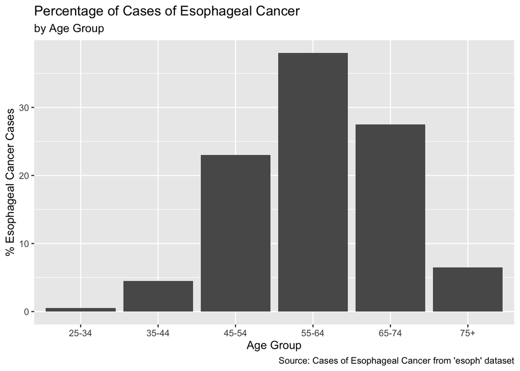

```r
# Add custom labels to the 'barchart'
barchart +
  labs(title = "Percentage of Cases of Esophageal Cancer", # Title
       subtitle = "by Age Group", # Subtitle
       x = "Age Group", # X-axis label
       y = "% Esophageal Cancer Cases", # Y-axis label
       caption = "Source: Cases of Esophageal Cancer from 'esoph' dataset") # Caption
```

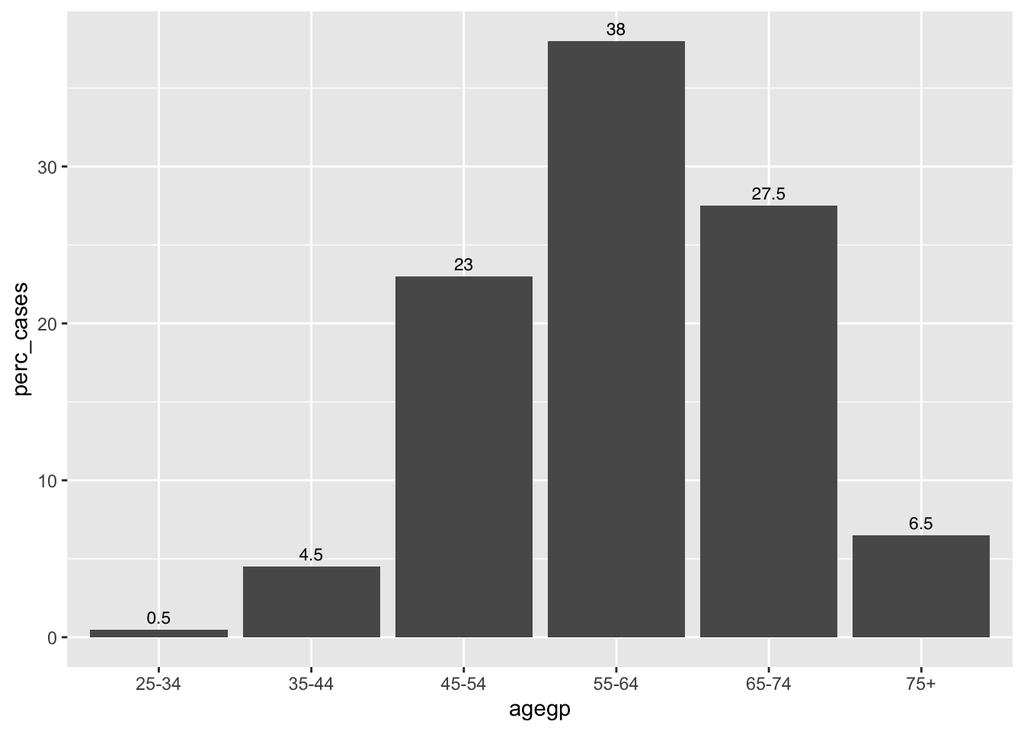

```r
# Add text labels above each bar using the 'perc_cases' values as labels
barchart +
  geom_text(aes(label = perc_cases), # Add text labels to each bar
                vjust = -0.5, # Adjust vertical placement (- is up, + is down)
                size = 3, # Adjust text size
                color = "black", # Set color
                family = "sans" # Set font
            )
```

# PART 2: COLOR

## 2.1: HOW TO ADD COLOR

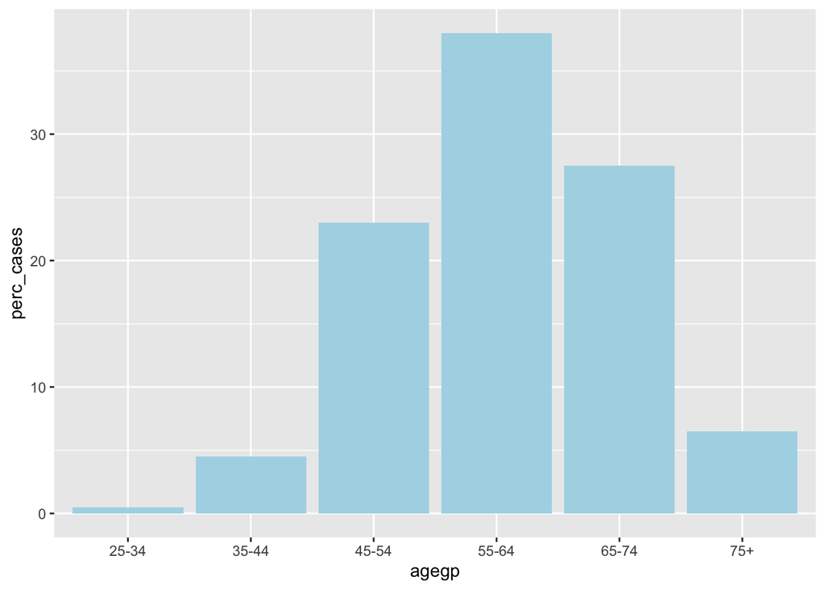

```r
# One color for all bars
barchart +
  geom_bar(stat="identity", # Directly plots provided data values as bar heights, without transformation
           fill="lightblue") # Filling in the bars
```

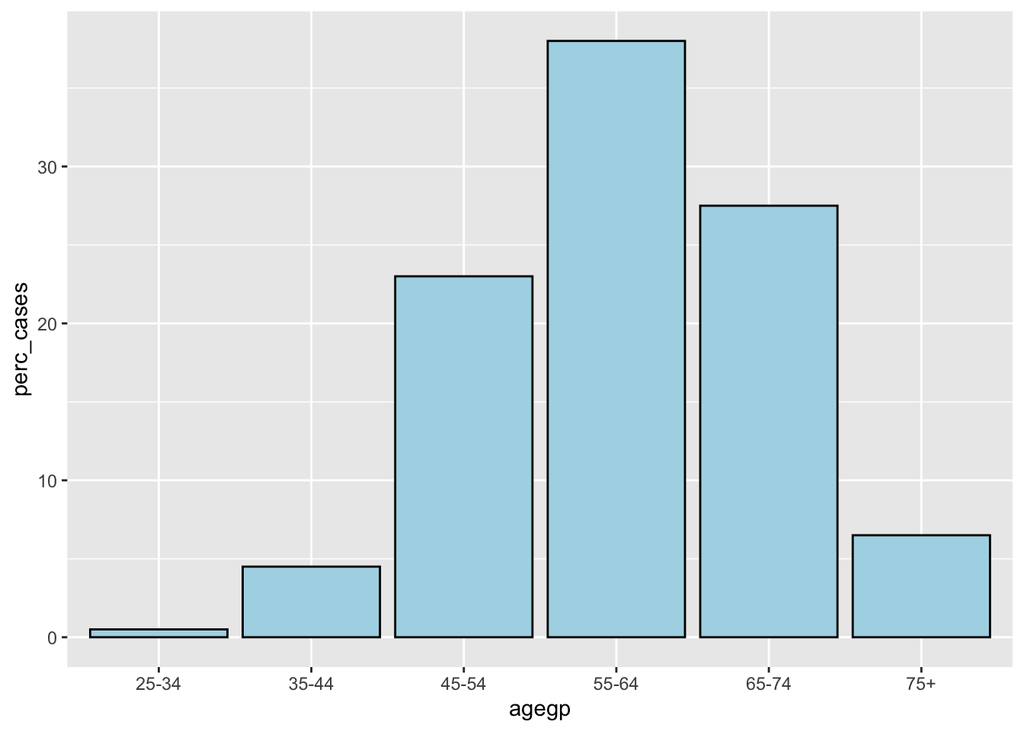

```r
# Outline and fill in the bars
barchart +
  geom_bar(stat = "identity",
           fill = "lightblue",
           color = "black") # Outlining the bars
```

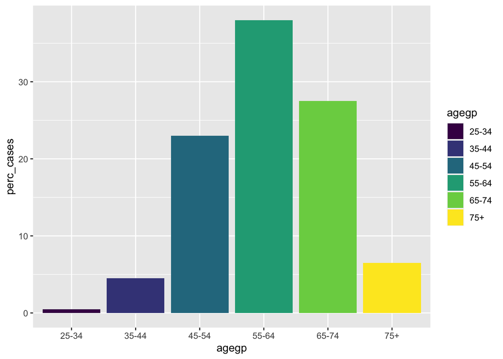

```r
# Color by Group (More useful for stacked barcharts which are covered later in this module)

# Use default colors:
barchart2 <- ggplot(agg_agegp, aes(x=agegp, y=perc_cases, fill = agegp)) +
  geom_bar(stat="identity")
barchart2
```

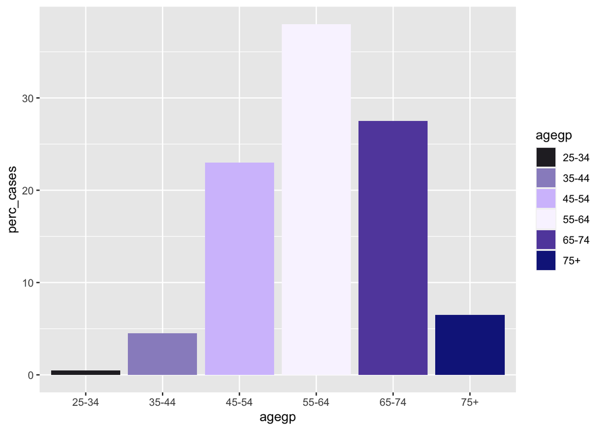

```r
# We can also manually select the fill colors:
   # (1) HEX Colors
     barchart2 + scale_fill_manual(values=c("#28262C", "#998FC7", "#D4C2FC",
                                          "#F9F5FF", "#624CAB", "#14248A"))
```

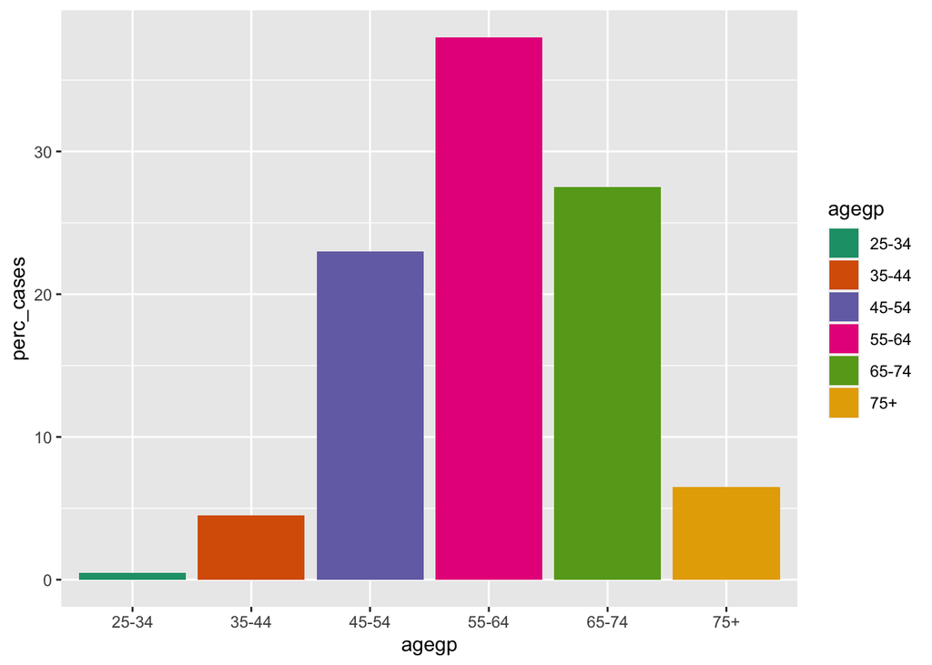

```r
    # (2) Color Palettes (i.e. Brewer's)
      barchart2 + scale_fill_brewer(palette="Dark2")
```

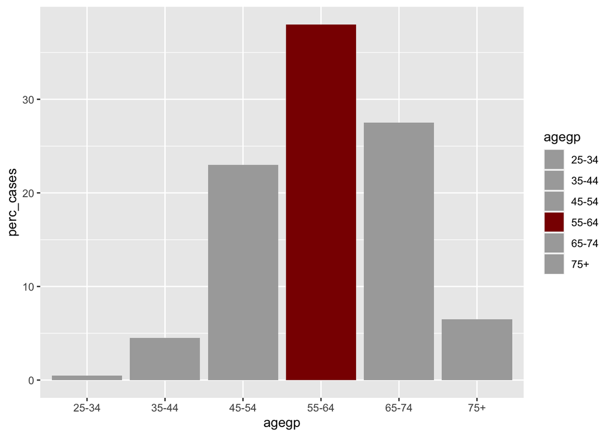

```r
  # A useful use case is to emphasize one of the groups
      barchart2 + scale_fill_manual(values=c("darkgrey", "darkgrey", "darkgrey",
                                          "darkred", "darkgrey", "darkgrey"))
```

## 2.2: COLOR USE CASES

### 2.2.1: Color to depict quantity (When you want the emphasis to be on a continuous value)

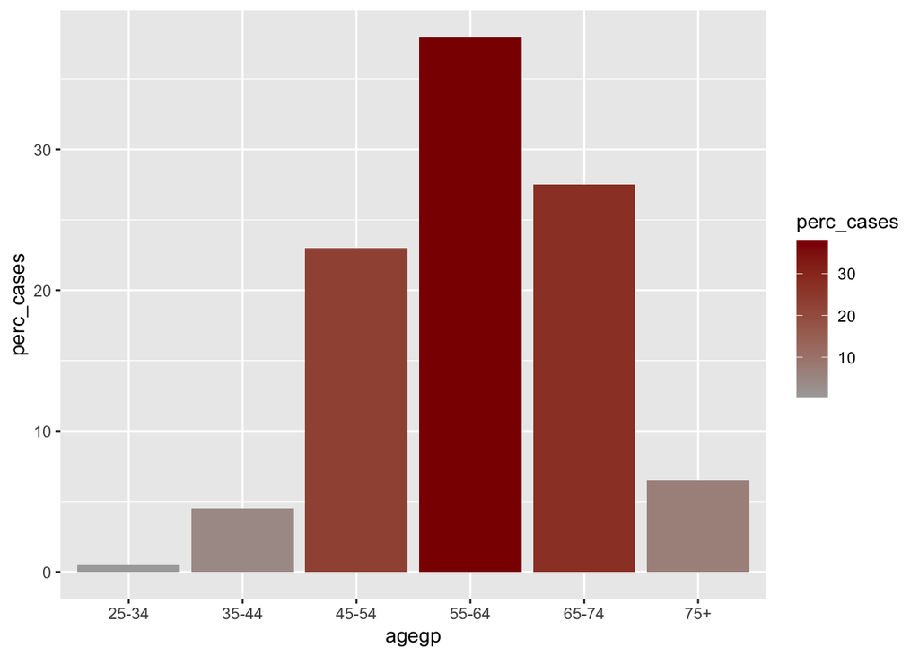

```r
barchart_continuous <- ggplot(agg_agegp, aes(x = agegp,
                                   y = perc_cases)) + # Key is to fill with continuous value
  geom_bar(stat = "identity", aes(fill = perc_cases)) +
  scale_fill_gradient(low = "darkgrey", high = "darkred")  # Apply color gradient
barchart_continuous
```

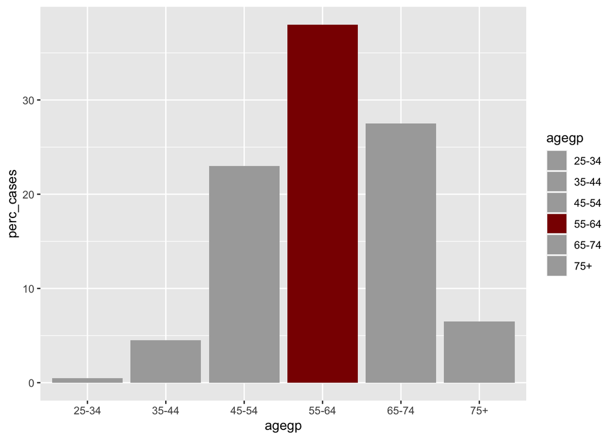

```r
# Color to highlight a specific group (When you want to emphasize one of the groups)
barchart2 +
  scale_fill_manual(values=c("darkgrey", "darkgrey", "darkgrey",
                                          "darkred", "darkgrey", "darkgrey"))
```

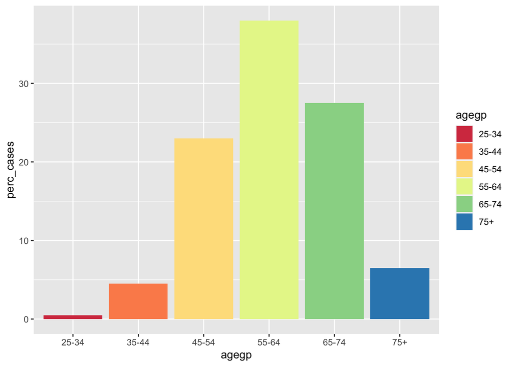

```r
# Color to distinguish between groups (Will become more useful in Stacked & Dodged bar plots!!)
barchart2 +
  scale_fill_brewer(palette="Spectral") # Use 'qualitative' or 'diverging' palettes for categorical data
```

## 2.3: LEGEND

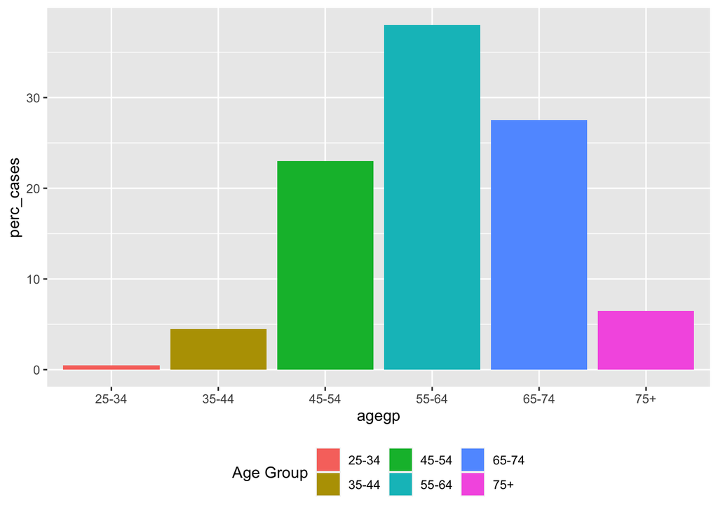

```r
# To modify the Legend:
barchart2 +
  scale_fill_brewer(palette="Accent") +
  scale_fill_discrete(name = "Age Group") + # Change name of Legend
  theme(legend.position="bottom") # Change position of legend (left, right, top, bottom)
```

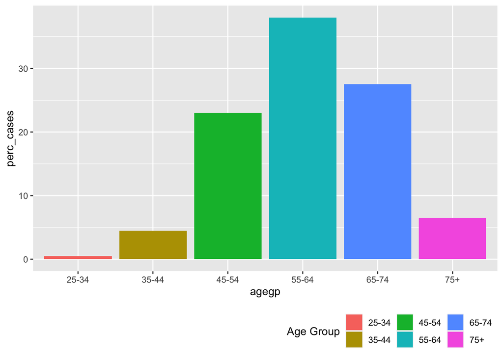

```r
barchart2 +
  scale_fill_brewer(palette = "Accent") +
  scale_fill_discrete(name = "Age Group") + # Change name of Legend
  theme(legend.position = "bottom",
        legend.justification = "right") # Another directioning position for combinations (top & right)
```

## 2.4: GRIDLINES/BACKGROUND

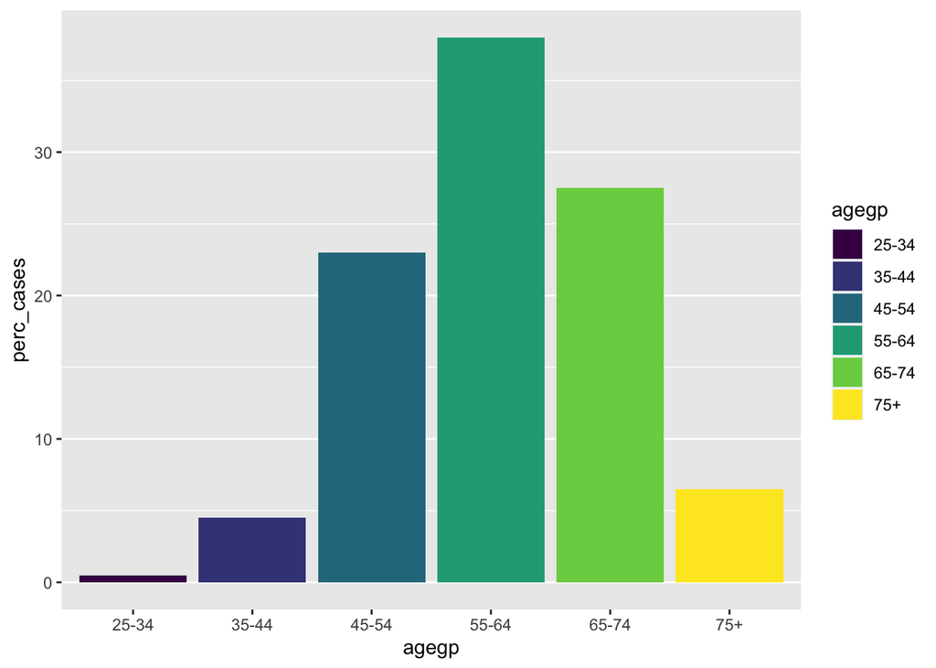

```r
# Remove Vertical Lines
barchart2 +
  theme(panel.grid.major.x = element_blank(),
        panel.grid.minor.x = element_blank())
```

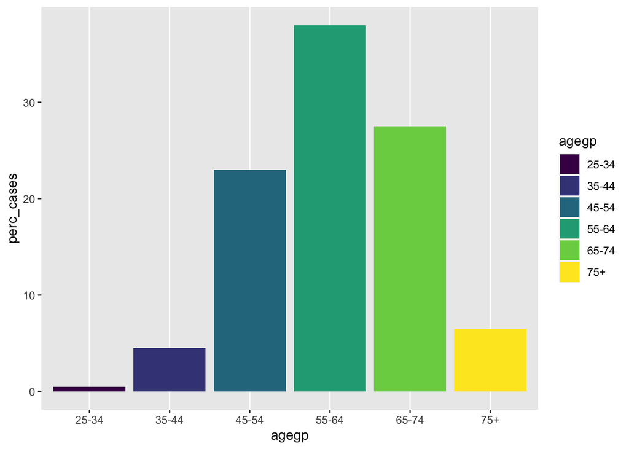

```r
# Remove Horizontal Lines
barchart2 +
    theme(panel.grid.major.y = element_blank(),
          panel.grid.minor.y = element_blank())
```

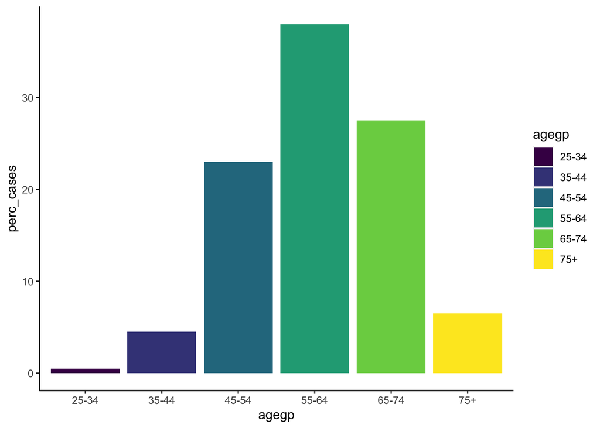

```r
# Remove both the lines and background
barchart2 +
    theme(panel.grid.major = element_blank(),
          panel.grid.minor = element_blank(),
          panel.background = element_blank(),
          axis.line = element_line(colour = "black"))
```

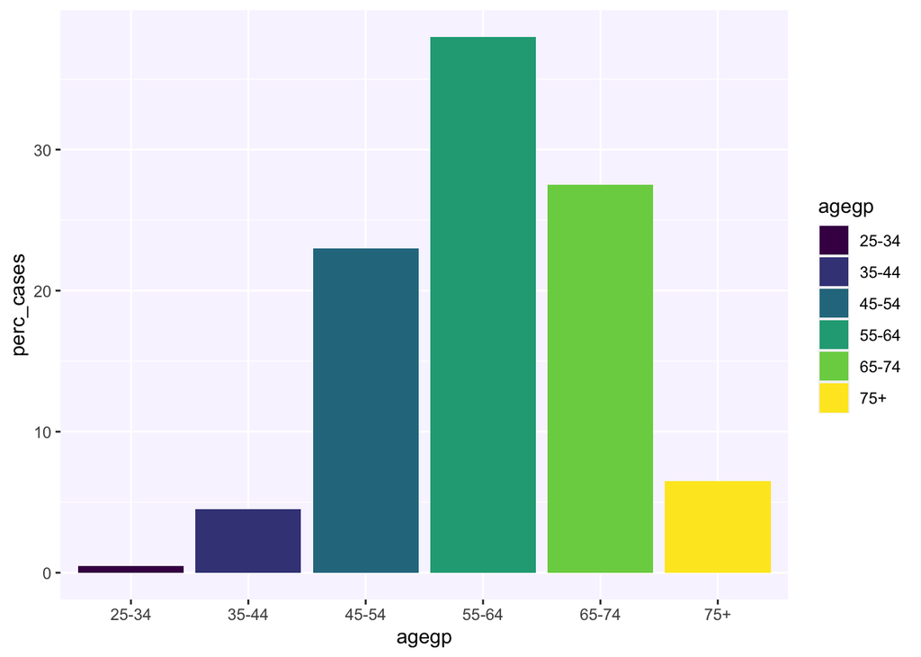

```r
# Add Custom background color
barchart2 +
    theme(panel.background = element_rect(fill = "#F9F5FF",
                                          size = 2, linetype = "solid"))
```

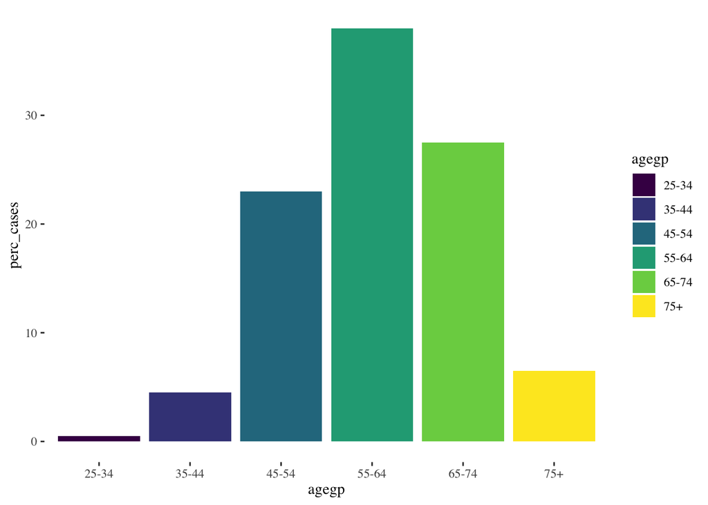

```r
# Use ggthemes to add/remove grid lines, change color of background, and change plot themes

# Example 1: Minimalist Theme
barchart2 +
  theme_tufte()
```

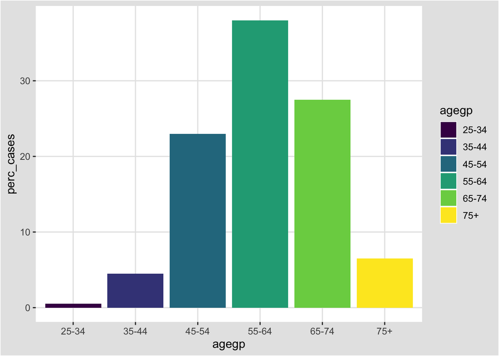

```r
# Example 2: Inverse Gray Theme
barchart2 +
  theme_igray()
```

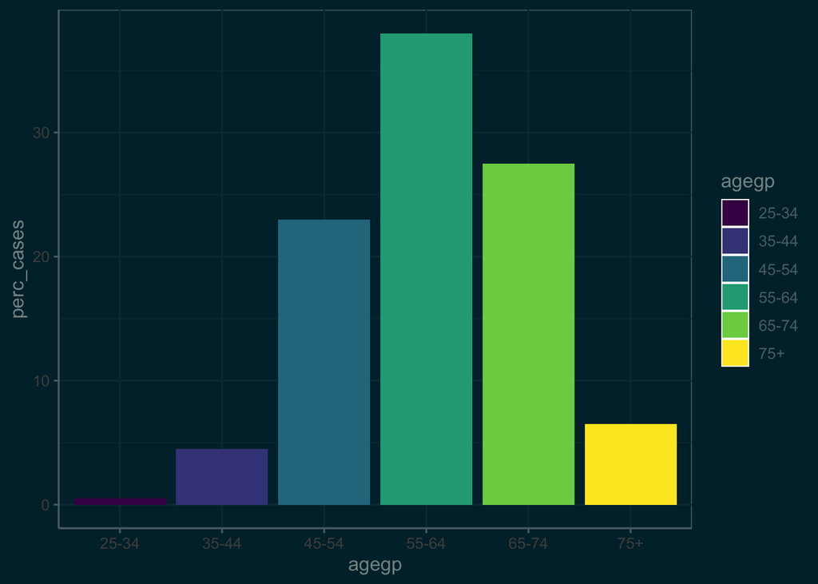

```r
# Example 3: Dark Theme
barchart2 +
  theme_solarized(light = FALSE)
```

TRY-IT-YOURSELF: We have individually gone through the methods to customize and elevate our plots. So, to produce a final, professional barchart, can you combine all of the modifications (i.e. Captions/Labels, Color, and Legend) above into a single call?

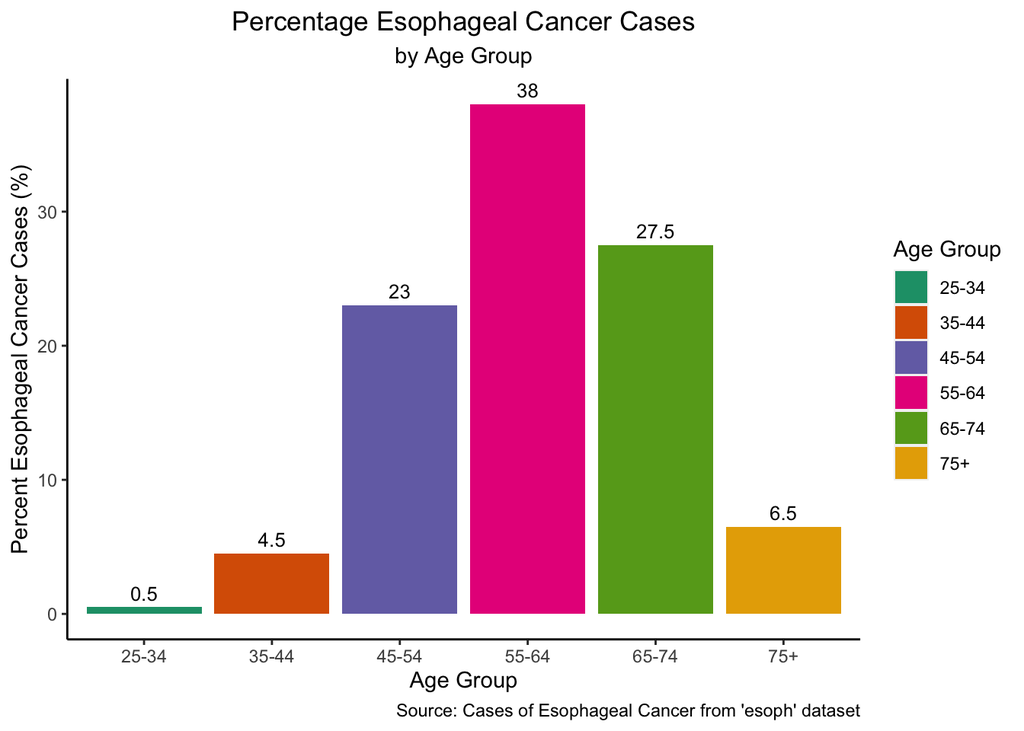

```r
#Type your answer here
custom_barchart <- ggplot(data=agg_agegp, aes(x=agegp, y=perc_cases, fill= agegp)) +
  geom_bar(stat="identity") +
  ggtitle("Percentage Esophageal Cancer Cases",
          subtitle = "by Age Group") +
  theme(plot.title = element_text(hjust = 0.5), plot.subtitle = element_text(hjust = 0.5)) +
  labs(x = "Age Group",
       y = "Percent Esophageal Cancer Cases (%)",
       caption = "Source: Cases of Esophageal Cancer from 'esoph' dataset") +
  guides(fill=guide_legend(title="Age Group")) +
  geom_text(aes(label = perc_cases), vjust = -0.50, size = 3.4, color = "black") +
  scale_fill_brewer(palette="Dark2") +
  theme(panel.grid.major = element_blank(), # Same as theme_classic()
          panel.grid.minor = element_blank(),
          panel.background = element_blank(),
          axis.line = element_line(colour = "black"))
custom_barchart
```

# PART 3: TYPES OF BARCHARTS

Alright, so we have explored how to modify regular barcharts to make them more professional and presentable.

In this part of the module, we will dive into creating more complex barcharts such as grouped and stacked barcharts.

# 3.1: STACKED BARCHART

Earlier, we compared the number and percent of cases of esophageal cancer by age group and noticed that some age groups tended to have a higher percentage of cases than others. To explore this relationship more, let’s look at how the number of cases are broken down by each age group’s alcohol consumption.

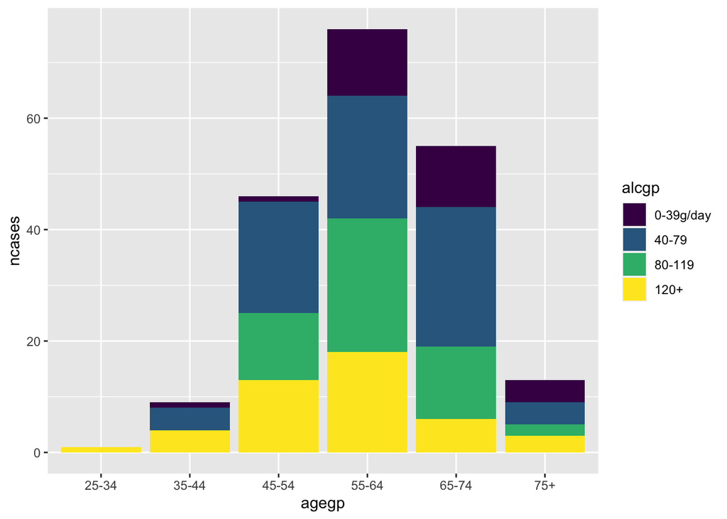

```r
stacked_bc <- ggplot(esoph, aes(x = agegp, y = ncases, fill = alcgp)) +
    geom_bar(stat = "identity")

stacked_bc
```

What do you notice about the distribution of alcohol consumption across the age groups?

Currently, our stacked barchart is using the default colors which may or may not look great or fit with our theme.

## 3.1.1: COLOR

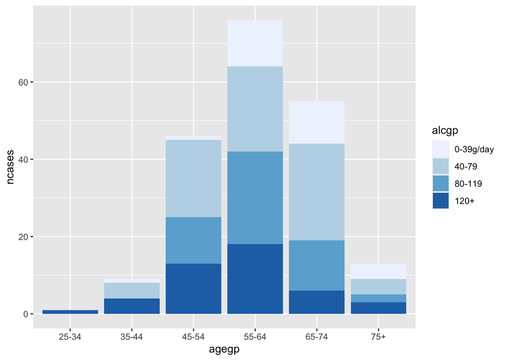

```r
# Color Palettes
stacked_bc + scale_fill_brewer() #Default Brewer color palette
```

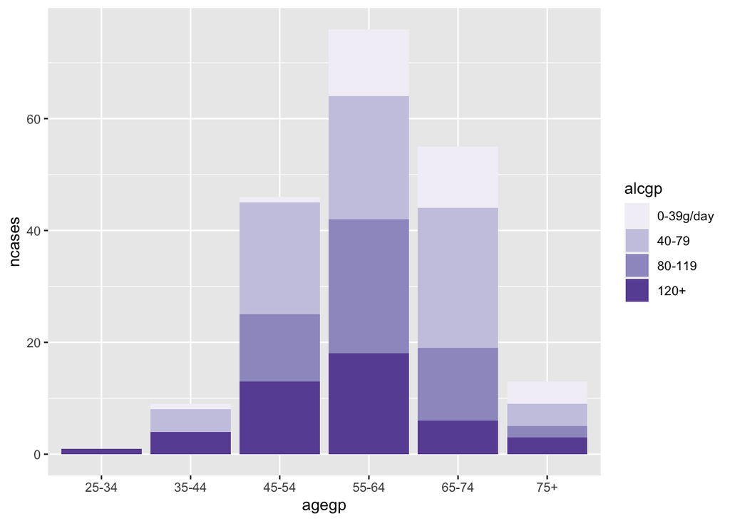

```r
# Can specify the palette by palette name or number
stacked_bc + scale_fill_brewer(palette = 12) #OR
```

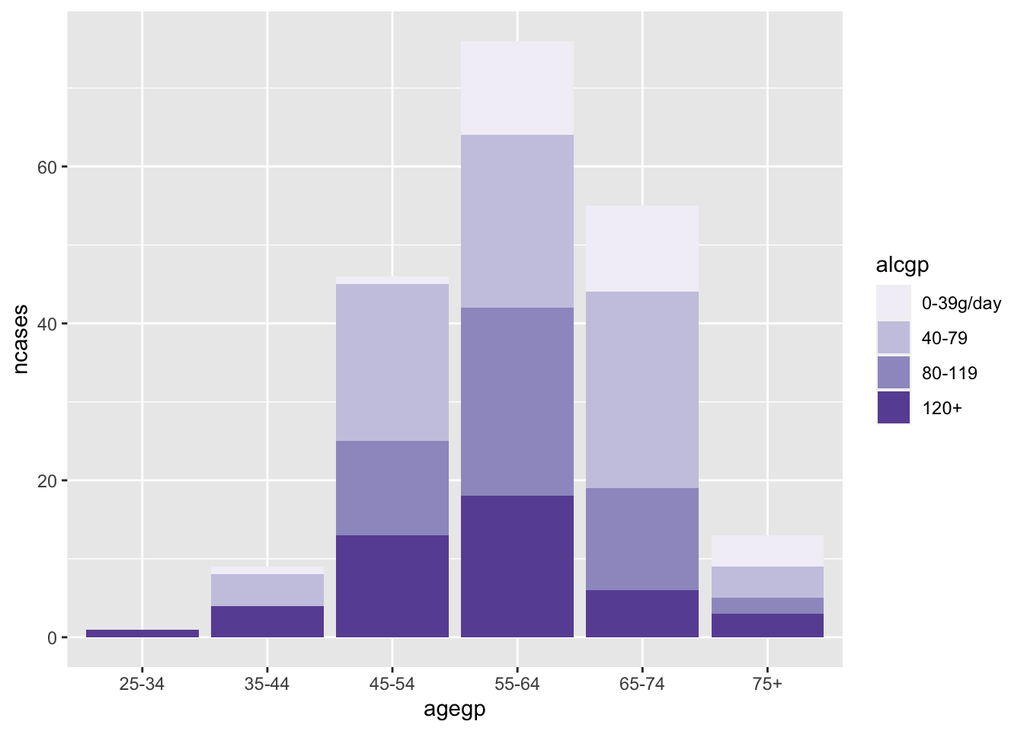

```r
stacked_bc + scale_fill_brewer(palette = "Purples")
```

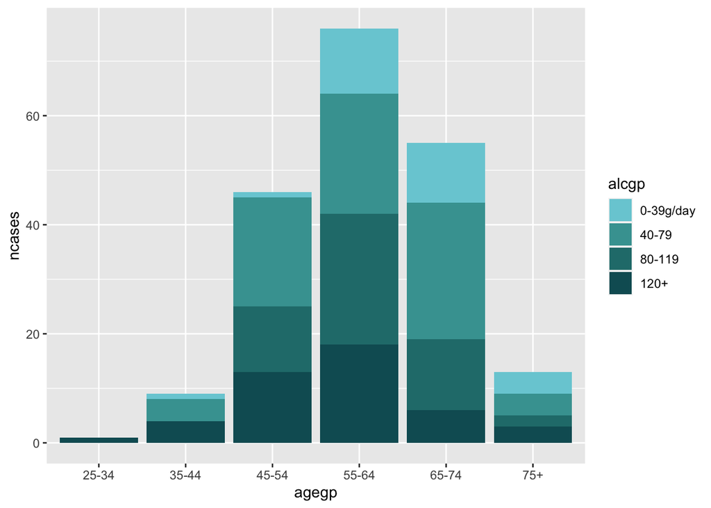

```r
# Manually Choose Colors for what you are stratifying by (i.e. alcgp)
stacked_bc + scale_fill_manual(values=c("#78CDD7", "#44A1A0", "#247B7B", "#0D5C63"))
```

## 3.1.2: BORDER

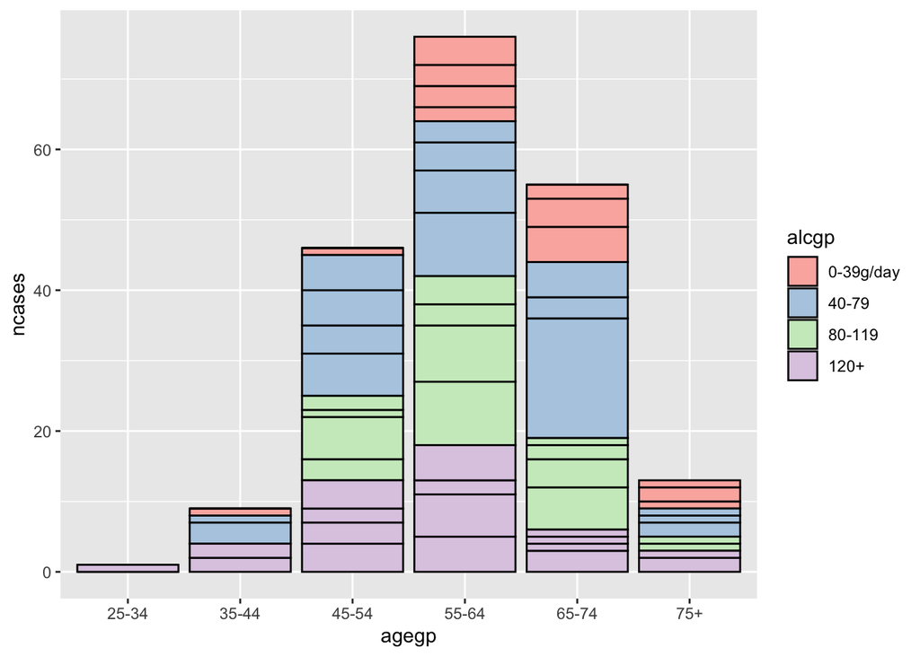

```r
# Add Border and Color
ggplot(esoph, aes(x = agegp, y = ncases, fill = alcgp)) +
  geom_bar(stat = "identity", color = "black") + #Specify Border by "color ="
  scale_fill_brewer(palette = "Pastel1")
```

```r
# The borders look a bit weird due to the way the data is represented in our dataset
# (We have the same alcgp category duplicated multiple times for each agegp)

# To get the proper border, we will need to clean our data such that
# the alcgp category is not repeated for each agegp
alc_cases <- esoph %>%
  select(agegp, alcgp, ncases) %>%
  group_by(agegp, alcgp) %>%
  summarize(total_cases = sum(ncases))
```

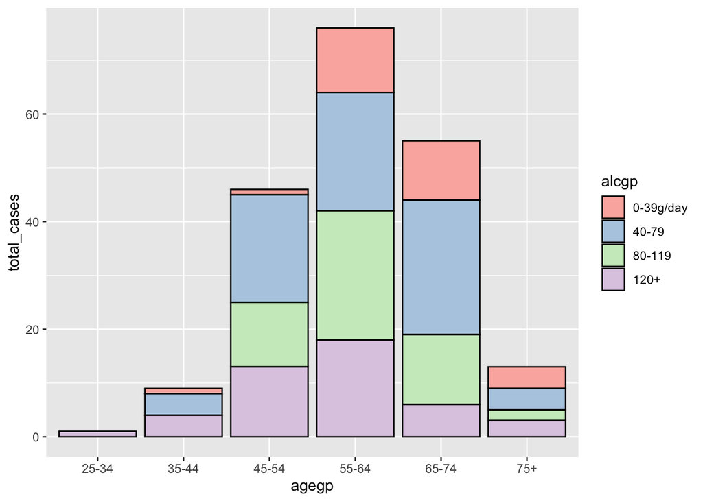

```r
# Compare this new clean data with the original dataset.
# What do you notice about the ways agegp, alcgp, and ncases are represented?

barchart3 <- ggplot(alc_cases, aes(x = agegp, y = total_cases, fill = alcgp)) +
  geom_bar(stat = "identity",color = "black") +
  scale_fill_brewer(palette = "Pastel1")

barchart3
```

```r
# Now the borders look good!
```

## 3.1.3: LABELS

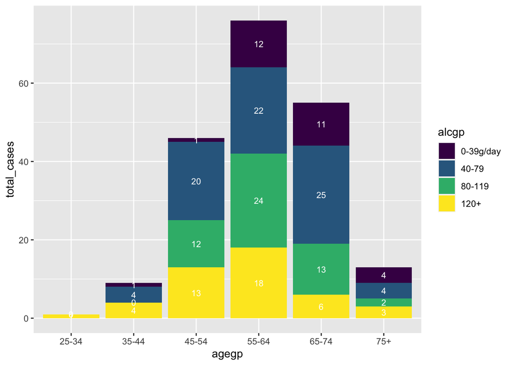

```r
ggplot(alc_cases, aes(x = agegp, y = total_cases, fill = alcgp,
                      label = total_cases)) + # Need to specify the label
  geom_bar(stat = "identity") +
  geom_text(position = position_stack(vjust = 0.5), size = 3, color = "#ffffff")
```

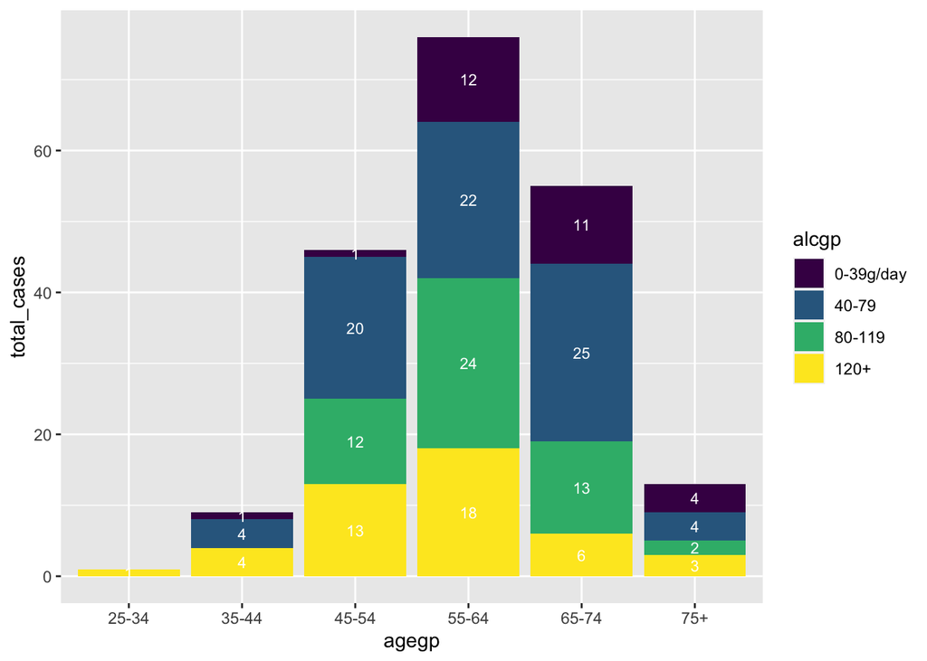

```r
# need to mention position = position_stack(); vjust = 0.5 is for centering

# In this case, this barchart is showing the values of 0, which we don't want,
# so we can modify our code
ggplot(alc_cases, aes(x=agegp, y=total_cases, fill = alcgp,
                      label = total_cases)) +
  geom_bar(stat="identity")+
  geom_text(data=subset(alc_cases, total_cases != 0),
            position = position_stack(vjust = 0.5), size=3, color = "#ffffff")
```

## 3.1.4: LEGEND

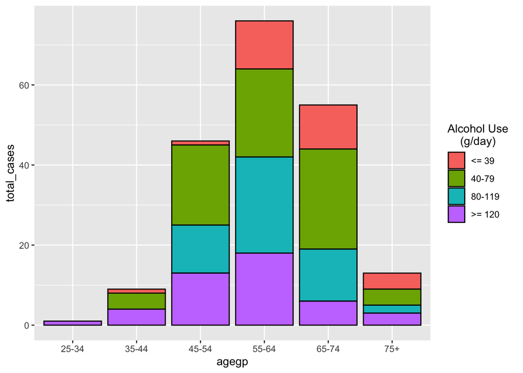

```r
# Change the Category Labels
barchart3 +
  guides(fill=guide_legend( # 'Guide legend' allows to manually input a legend
    title="Alcohol Use \n    (g/day)")) + # '\n' adds a new line and then add spaces to center '(g/day)'
  scale_fill_discrete(labels = c("<= 39", "40-79", "80-119", ">= 120"))
```